# R course day 2: Statistics

## 2.2 Non-paramteric: Wilcoxon test

We have seen how to perform a t-test to compare if the mean of two groups is the same. However, we assumed that our data was normally distributed. Large outliers can heavily influence the sample mean and standard deviation, which would influence the t-test result. But what if during recording of the petal lengths the wrong values had been added?  
Let’s change three values to simulate such outliers:

```r
vers_pl[1] <- 15
vers_pl[2] <- 17
vers_pl[3] <- 14
```

Now run the t-test again:

```r
t.test(virg_pl,vers_pl)
```

```
##
##  Welch Two Sample t-test
##
## data:  virg_pl and vers_pl
## t = 1.6666, df = 53.03, p-value = 0.1015
## alternative hypothesis: true difference in means is not equal to 0
## 95 percent confidence interval:
##  -0.1330538  1.4410538
## sample estimates:
## mean of x mean of y
##     5.552     4.898
```

The t-test is no longer significant.

**Q7**:

- Run the wilcoxon test on the same data (`wilcox.test`, type `?wilcox.test` to see examples of how to use it)
- Is the p-value lower or higher? (type `?wilcox.test` for examples how to use it)

```r
#Question 7
#Code
wilcox.test(virg_pl, vers_pl)
```

```
##
##  Wilcoxon rank sum test with continuity correction
##
## data:  virg_pl and vers_pl
## W = 2311.5, p-value = 2.466e-13
## alternative hypothesis: true location shift is not equal to 0
```

```r
#Answer
#The p-value is highly significant and much lower than the p-value from the t-test. It appears this test deals better with outliers.
```

The Wilcoxon test merges the data together, ranks each point from lowest to highest values, separates the ranks back to the two groups, and using the sum or average rank calculates the test-statistics.

**Q8**:

- Make a plot of the values (including the changes you just added) using the code below
- Read the stripchart help page
- When would you typically use a stripchart?

```r
stripchart(list(virg_pl, vers_pl),
           vertical=TRUE,
           ylab="Observations",
           pch=21,
           bg=1)
```

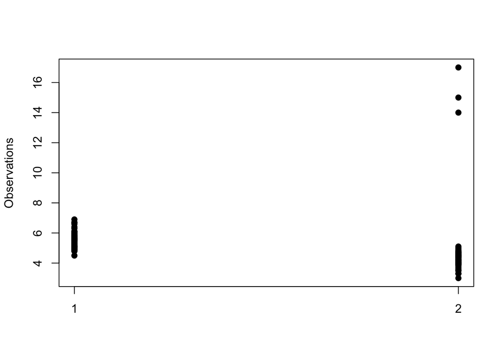

```r
#Question 8
#Code
stripchart(list(virg_pl, vers_pl),
           vertical=TRUE,
           ylab="Observations",
           pch=21,
           bg=1)
```

```r
#Answer
#The plots are used to show the differences between two groups when the sample size is small
```

As you can see in your plot, there is a big gap between the outlier points that we just introduced and the normal points.

**Q9**:

- Make two plots of the real and ranked values using the code below
- Why is the wilcoxon test better for data with outliers?

```r
# par() is a function that allows multiple plots to be combined in one figure
# 1 = the number of rows, 2 = the number of columns
par(mfrow=c(1,2))

#select the first 50 numbers using seq(along=virg_pl)
#the along argument gives the number (50) of observations you want to select
#select the last 50 numbers using the negative seq: -seq(along=virg_pl)
xrank <- rank(c(virg_pl,vers_pl))[seq(along=virg_pl)]
yrank <- rank(c(virg_pl,vers_pl))[-seq(along=virg_pl)]

# plot the previous plot for comparison
stripchart(list(virg_pl, vers_pl),
           vertical=TRUE,
           ylab="Observations",
           pch=21,
           bg=1)
stripchart(list(xrank,yrank),
           vertical=TRUE,
           ylab="Ranks",
           pch=21,bg=1,
           cex=1.25)
```

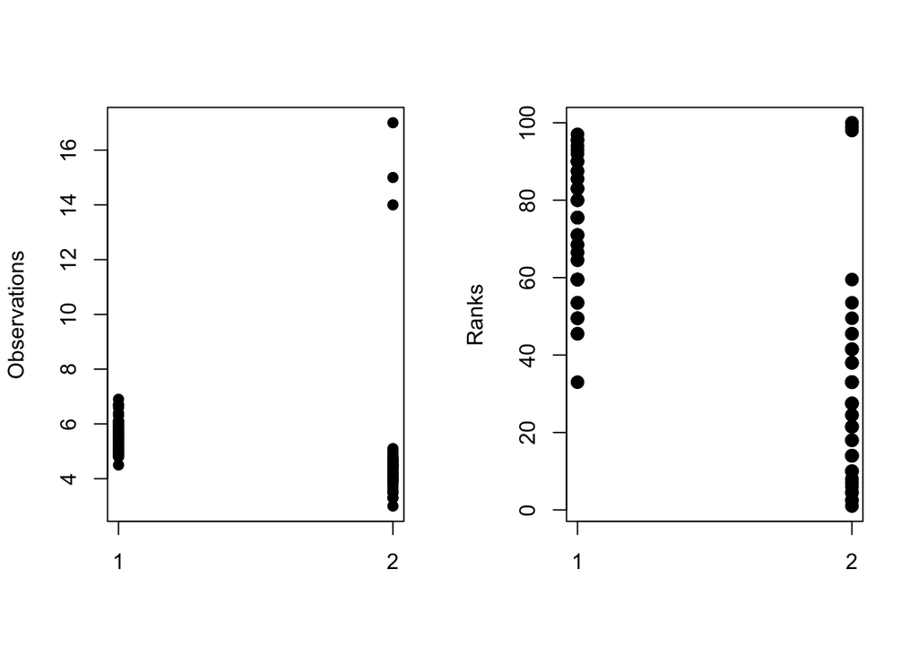

```r
#Question 9
#Code
par(mfrow=c(1,2))

xrank <- rank(c(virg_pl,vers_pl))[seq(along=virg_pl)]
yrank <- rank(c(virg_pl,vers_pl))[-seq(along=vers_pl)]
# plot the previous plot for comparison
stripchart(list(virg_pl, vers_pl),
           vertical=TRUE,
           ylab="Observations",
           pch=21,
           bg=1)
abline(h=0)
stripchart(list(xrank,yrank),
           vertical=TRUE,
           ylab="Ranks",
           pch=21,bg=1,
           cex=1.25)
```

```r
#Answer
#Because it makes the gap between outliers and the other data smaller, ensuring that those points are not the most important in calculating the differences between the two groups.
```

# 3 Differences between more than 2 groups

Sometimes, we want to know the difference between not just 2 groups, but between more than 2 groups. For example, in the **iris** data, there are 3 species of flower that we can investigate. Of course we can run a t-test or Wilcoxon test for each of the combinations, but we can also use an analysis of variance (ANOVA) or the non-parametric Krukal-Wallis test.

## 3.1 Parametric: ANOVA

If you want to compare the difference of mean values among multiple groups, you can use the ANOVA test. We want to examine whether the mean value of `Sepal.Length` differs among the different species of **iris**. We use the function `aov()` and we assign the result to `model1`.  
The tilde (`~`) must be read as the phrase ‘is modeled as a function of’. In this example, we would say: The length of iris sepals is modeled as a function of the iris species.

```r
model1 <- aov(Sepal.Length~Species, data = iris)
```

In general, the basic notation for a linear model or function notation in R is:

```r
response_variable ~ explanatory_variables
```

**Q10**:

- Use the function `summary()` to have a look at `model1`
- The p-value is in the column `Pr(>F)`
- Is the p-value significant for this test?
- What is the significance code for this test, and what does that mean?
- The degrees of freedom are in the column `Df`
- How many degrees of freedom are there for the `Species`?

```r
#Question 10
#Code
summary(model1)
```

```
##              Df Sum Sq Mean Sq F value Pr(>F)
## Species       2  63.21  31.606   119.3 <2e-16 ***
## Residuals   147  38.96   0.265
## ---
## Signif. codes:  0 '***' 0.001 '**' 0.01 '*' 0.05 '.' 0.1 ' ' 1
```

```r
#Answer
#The p-value is highly signifciant: <2e-16
#The significance code is ***, which indicates a level of below 0.001
#There are 2 degrees of freedom, that makes sense because there are 3 species (df = variables-1)
```

## 3.2 Non-parametric: Kruskal-Wallis test

The same test without the assumption of normality (i.e. non-parametric test) is called the Kruskal-Wallis test.

**Q11**:

- Use the function `kruskal.test()` to calculate the differences between the **length** of the sepals across the three species
- Save the output in `model2`
- Use the function `kruskal.test()` to calculate the differences between the **width** of the sepals across the three species
- Save the output in `model3`
- Is there a difference in significance between `model1` and `model2`?
- What is the p-value for `model3`?
- What can you conclude about the relationship between sepal length and iris species? Is the species important for the sepal length? How about for the sepal width?

```r
#Question 11
#Code
model2 <- kruskal.test(Sepal.Length~Species, data = iris)
model3 <- kruskal.test(Sepal.Width~Species, data = iris)

summary(model1)[[1]][["Pr(>F)"]]
```

```
## [1] 1.669669e-31           NA
```

```r
model2$p.value
```

```
## [1] 8.918734e-22
```

```r
model3$p.value
```

```
## [1] 1.569282e-14
```

```r
#Answer
#P-values of model1 and model2 are both highly significant, model1 a bit more so
#model3 p-value is 1.569282e-14, also significant but less so than the sepal length model
#Both length and width of sepal is dependent on the species of iris
```

# 4 Differences between paired samples

In other instances, you might be interested to understand the differences between samples that are linked (or ‘paired’) to one another. For example, if you have an experiment with two measurements before and after a treatment from the same sample. Because you are looking at data from the same individual, the measurements before and after will be ‘paired’.